# Analyse Stratégique : Bac Lettres Tunisie 2025

Opportunités face à la chute du taux de réussite au Baccalauréat

Author

Maroua Hattab

Published

January 7, 2026

# 1 Introduction : Le Contexte du Défi

## 1.1 Une Baisse Alarmante du Taux de Réussite au Baccalauréat Lettres

Le système éducatif tunisien fait face à un défi majeur en 2025 : **le taux de réussite au baccalauréat section Lettres connaît une chute significative**.

| Session | Taux de Réussite | Évolution |
| --- | --- | --- |
| **2024** | 44.33% | - |
| **2025** | 39.10% | **-5.23 points** |

Cette baisse de plus de **5 points de pourcentage** représente une diminution relative de **11.8%** du nombre de bacheliers lettres potentiels.

### 1.1.1 Questions Clés de cette Analyse

Face à cette réduction du vivier de candidats, quelles sont les opportunités qui s’offrent réellement aux bacheliers lettres en Tunisie ?

1. **Accessibilité** : Quelles filières ont des scores d’entrée plus accessibles en 2025 vs 2024 ?
2. **Répartition géographique** : Comment les offres sont-elles distribuées sur le territoire tunisien ?
3. **Diversité des formations** : Quels domaines et spécialisations sont disponibles ?
4. **Conditions d’admission** : Quelles contraintes spécifiques (sport, langue, âge) peuvent limiter l’accès ?
5. **Tendances** : Les scores d’orientation baissent-ils parallèlement au taux de réussite ?

# 2 Phase I : Nettoyage et Préparation des Données

## 2.1 Introduction au Nettoyage

Cette Partie nettoie et standardise les données des filières universitaires en Tunisie. L’effort de nettoyage est l’aspect le plus critique de ce projet. Les données brutes collectées depuis le Portail Officiel de l’Orientation (RNU) étaient particulièrement complexes et nécessitaient un traitement approfondi pour être exploitables.

### 2.1.1 Les défis majeurs identifiés :

- **Méta-données corrompues** : Les noms de colonnes contenaient des sauts de ligne (`\n`) et des tabulations (`\t`) rendant impossible l’appel des variables dans le code.
- **Incohérence textuelle** : Des variantes comme “l en sc. infirmieres” vs “Licence en Sciences Infirmières” créaient des doublons artificiels.
- **Valeurs vides ambiguës** : Utilisation de termes comme “Rien” ou “03 ans” dans des colonnes de conditions d’éligibilité.

## 2.2 1. Chargement des bibliothèques

```r
# Chargement des bibliothèques
library(readxl)    # Pour lire les fichiers Excel
library(dplyr)     # Pour la manipulation des données
library(stringr)   # Pour la manipulation des chaînes
library(tidyr)     # Pour le nettoyage des données
cat("Bibliothèques chargées avec succès\n")
```

```
Bibliothèques chargées avec succès
```

## 2.3 2. Chargement des données

```r
# Lecture du fichier Excel
df <- read_excel("Data/data.xlsx", sheet = 1)

# Affichage de la structure
cat("Dimensions initiales:", nrow(df), "lignes x", ncol(df), "colonnes\n")
```

```
Dimensions initiales: 240 lignes x 10 colonnes
```

```r
cat("\nNoms des colonnes originales:\n")
```

```
Noms des colonnes originales:
```

```r
print(colnames(df))
```

```
 [1] "Filiere"                 "Université"
 [3] "Etablissement"           "Gouvernorat"
 [5] "Critères"                "Durée\r\ndes\r\nEtudes"
 [7] "S.D.\r\nOrionté\r\n2025" "S.D.\r\nOrionté\r\n2024"
 [9] "Conditions :"            "Spécialités :"
```

**Observation** : Les données brutes contiennent 240 lignes et 10 colonnes. Les noms de colonnes contiennent des caractères spéciaux (sauts de ligne, tabulations) qui nécessitent un nettoyage.

## 2.4 3. Nettoyage des noms de colonnes

```r
# Suppression des sauts de ligne, tabulations, espaces multiples et deux-points
colnames(df) <- colnames(df) %>%
  str_replace_all("\n", " ") %>%       # Remplacer \n par espace
  str_replace_all("\t", " ") %>%       # Remplacer \t par espace
  str_replace_all(":", "") %>%         # Supprimer les :
  str_replace_all("\\s+", " ") %>%     # Remplacer espaces multiples
  str_trim()                            # Supprimer espaces début/fin

cat("Nouveaux noms de colonnes:\n")
```

```
Nouveaux noms de colonnes:
```

```r
print(colnames(df))
```

```
 [1] "Filiere"           "Université"        "Etablissement"
 [4] "Gouvernorat"       "Critères"          "Durée des Etudes"
 [7] "S.D. Orionté 2025" "S.D. Orionté 2024" "Conditions"
[10] "Spécialités"
```

**Observation** : Après nettoyage, les noms de colonnes sont standardisés et exploitables. Les caractères spéciaux ont été supprimés.

## 2.5 4. Nettoyage de la colonne ‘Filiere’

```r
# Suppression des lignes avec Filiere vide
df <- df %>% filter(!is.na(Filiere))

# Nettoyage de base
df <- df %>%
  mutate(Filiere = Filiere %>%
           str_replace_all("\n", " ") %>%
           str_replace_all("\\s+", " ") %>%
           str_trim() %>%
           tolower())

# Standardisation du préfixe "L EN"
df <- df %>%
  mutate(Filiere = str_replace(Filiere, "^l\\.?\\s*en\\s*", "l en "))

# Corrections d'abréviations
df <- df %>%
  mutate(Filiere = str_replace(Filiere, "l en sc\\. infirmieres", "l en sciences infirmieres"),
         Filiere = str_replace(Filiere, "l en tech\\.", "l en techniques"))

cat("Nombre de filières uniques après nettoyage:", length(unique(df$Filiere)), "\n")
```

```
Nombre de filières uniques après nettoyage: 71
```

**Observation** : Après nettoyage initial, nous avons 71 filières uniques. Cependant, certaines variantes nécessitent encore une standardisation.

```r
# Mapping des filières vers des noms cohérents
filiere_mapping <- c(
  'l en sciences de l education' = 'l en sciences de l éducation',
  'l en science et techniques des activités physiques et sportives' = 'l en sciences physiques et sportives',
  'l en physiothérapie' = 'l en santé: physiothérapie',
  'l en orthophonie' = 'l en santé: orthophonie',
  'l en nutrition humaine' = 'l en santé: nutrition',
  'l en ergothérapie' = 'l en santé: ergothérapie',
  'l en puériculture' = 'l en santé: puériculture',
  'l en sciences maïeutiques sage femme' = 'l en santé: sage-femme',
  'l en documentbibliothéconomie et archiv' = 'l en documentation et bibliothéconomie',
  'l en gestion élect de l infor et des docu' = 'l en gestion informatique documentaire',
  'l en médiation et animation' = 'l en médiation culturelle',
  'l en théa arts de la scène' = 'l en théâtre et arts de la scène',
  'prépalettre spécialité arabe' = 'prépa lettres arabe',
  'prépalettre spécialité français' = 'prépa lettres français',
  'prépalettre spécialité anglais' = 'prépa lettres anglais',
  'cycle prépasciences humaines histoire' = 'cycle prépa sciences humaines histoire',
  'cycle prépasciences humaines géographie' = 'cycle prépa sciences humaines géographie',
  'cycle prépasciences humaines philosophie' = 'cycle prépa sciences humaines philosophie',
  'l en arts du patrimoine islamique' = 'l en patrimoine islamique',
  'l en science islamique' = 'l en sciences islamiques',
  'l en géographie de lenvironnement' = 'l en géographie de l environnement',
  'l en techniques agroalimentaires et envir' = 'l en techniques agroalimentaires et environnement'
)

# Application du mapping
for (old_name in names(filiere_mapping)) {
  df <- df %>%
    mutate(Filiere = if_else(Filiere == old_name, filiere_mapping[old_name], Filiere))
}

cat("Mapping appliqué avec succès\n")
```

```
Mapping appliqué avec succès
```

**Conclusion** : La standardisation des noms de filières permet d’éviter les doublons et facilite les analyses ultérieures.

## 2.6 5. Nettoyage de la colonne ‘Université’

```r
df <- df %>%
  mutate(Université = Université %>%
           str_replace_all("\n", " ") %>%
           str_trim() %>%
           tolower())

cat("Universités uniques:\n")
```

```
Universités uniques:
```

```r
print(unique(df$Université))
```

```
 [1] "universite\r de tunis"        "universite de manouba"
 [3] "universite de tunis el manar" "universite de carthage"
 [5] "universite ez-zitouna"        "universite du sousse"
 [7] "universite du sfax"           "universite de jendouba"
 [9] "universite de gabes"          "universite de monastir"
[11] "universite de kairouan"       "universite de gafsa"
```

## 2.7 6. Nettoyage de la colonne ‘Etablissement’

```r
df <- df %>%
  mutate(Etablissement = Etablissement %>%
           str_replace_all("\n", " ") %>%
           str_replace_all("\t", " ") %>%
           str_trim() %>%
           tolower())

# Correction spécifique
df <- df %>%
  mutate(Etablissement = str_replace(Etablissement,
                                     'faculté de médecine â€" tunis',
                                     'faculté de médecine de tunis'))

cat("Nombre d'établissements uniques:", length(unique(df$Etablissement)), "\n")
```

```
Nombre d'établissements uniques: 83
```

**Observation** : 83 établissements uniques sont identifiés après nettoyage.

## 2.8 7. Nettoyage de la colonne ‘Gouvernorat’

```r
df <- df %>%
  mutate(Gouvernorat = Gouvernorat %>%
           str_trim() %>%
           str_to_title())  # Première lettre en majuscule

cat("Gouvernorats uniques:\n")
```

```
Gouvernorats uniques:
```

```r
print(unique(df$Gouvernorat))
```

```
 [1] "Tunis"       "Zaghouane"   "Nabeul"      "Kairouan"    "Sousse"
 [6] "Sfax"        "Jendouba"    "Le Kef"      "Beja"        "Siliana"
[11] "Gabes"       "Mednine"     "Tataouine"   "Monastir"    "Mahdia"
[16] "Kasserine"   "Sidi Bouzid" "Gafsa"       "Tozeur"
```

**Observation** : 19 gouvernorats sont représentés, avec une standardisation de la casse pour faciliter les analyses géographiques.

## 2.9 8. Nettoyage de la colonne ‘Critères’

```r
df <- df %>%
  mutate(Critères = Critères %>%
           str_replace_all("\n", "") %>%
           str_trim() %>%
           toupper())

cat("Critères uniques:\n")
```

```
Critères uniques:
```

```r
print(unique(df$Critères))
```

```
 [1] "FG+AR"              "FG+F"               "FG+ANG"
 [4] "FG+\r(HG+PH)/2"     "FG+PH"              "FG+\r(F+HG)/2"
 [7] "FG+(F+HG)/2"        "FG+(2AR+ANG+F)/4"   "FG+(AR+ANG+2F)/4"
[10] "FG+(AR+2ANG+F)/4"   "FG+(AR+F+HG+PH)/4"  "FG+(AR+FR)/2"
[13] "FG+ESP"             "FG+IT"              "FG+ALL"
[16] "FG+(F+ANG+HG)/3"    "FG+(AR+ANG+F+PH)/4" "FG+(AR+ANG+F)/3"
[19] "FG+(F+ANG+PH)/3"    "FG+INF"             "FG+SPT"
[22] "FG+SVT"             "FG+(HG+PH)/2"       "FG+HG"
[25] "FG+(F+ANG)/2"       "FG+(F+ANG+SPT)/3"
```

**Observation** : 26 formules de critères différentes sont utilisées pour calculer les scores d’orientation, toutes standardisées en majuscules.

## 2.10 9. Nettoyage de la colonne ‘Durée des Etudes’

```r
# Remplissage des valeurs manquantes
df <- df %>%
  mutate(`Durée des Etudes` = if_else(is.na(`Durée des Etudes`), "03 ans", `Durée des Etudes`))

# Uniformisation du format
df <- df %>%
  mutate(`Durée des Etudes` = `Durée des Etudes` %>%
           str_replace_all("\\s+", " ") %>%
           str_trim() %>%
           str_replace("03  ans", "03 ans"))

cat("Durées d'études uniques:\n")
```

```
Durées d'études uniques:
```

```r
print(unique(df$`Durée des Etudes`))
```

```
[1] "03 ans" "02 ans" "09 ans" "06 ans"
```

**Observation** : Quatre durées d’études sont identifiées : 02 ans, 03 ans, 06 ans, et 09 ans. La majorité des filières (93.3%) durent 3 ans.

## 2.11 10. Vérification et nettoyage des scores (2025 et 2024)

```r
# Afficher les noms exacts des colonnes pour diagnostic
cat("Noms de colonnes contenant 'Orient':\n")
```

```
Noms de colonnes contenant 'Orient':
```

```r
print(grep("Orient", colnames(df), value = TRUE, ignore.case = TRUE))
```

```
character(0)
```

```r
# Identifier les colonnes de scores
col_2025 <- grep("2025", colnames(df), value = TRUE)[1]
col_2024 <- grep("2024", colnames(df), value = TRUE)[1]

cat("\nColonne 2025 détectée:", col_2025, "\n")
```

```
Colonne 2025 détectée: S.D. Orionté 2025
```

```r
cat("Colonne 2024 détectée:", col_2024, "\n")
```

```
Colonne 2024 détectée: S.D. Orionté 2024
```

```r
# Remplissage des valeurs manquantes par 0
# Utilisation de la notation avec crochets doubles pour éviter les problèmes d'accents
df[[col_2025]] <- ifelse(is.na(df[[col_2025]]), 0, df[[col_2025]])
df[[col_2024]] <- ifelse(is.na(df[[col_2024]]), 0, df[[col_2024]])

cat("\nValeurs manquantes remplacées par 0\n")
```

```
Valeurs manquantes remplacées par 0
```

```r
# Affichage des statistiques
cat("\nScore 2025 - min:", min(df[[col_2025]], na.rm = TRUE),
    "max:", max(df[[col_2025]], na.rm = TRUE), "\n")
```

```
Score 2025 - min: 0 max: 173.217
```

```r
cat("Score 2024 - min:", min(df[[col_2024]], na.rm = TRUE),
    "max:", max(df[[col_2024]], na.rm = TRUE), "\n")
```

```
Score 2024 - min: 0 max: 182.91
```

**Observation** : Les scores varient de 0 à 173.22 en 2025 et de 0 à 182.91 en 2024. Les valeurs manquantes ont été remplacées par 0 pour les nouvelles filières ou celles sans données.

## 2.12 11. Nettoyage de la colonne ‘Conditions’

```r
# Mapping des conditions
conditions_map <- c(
  'Rien' = 'aucune',
  '03 ans' = 'aucune',
  'Sport exigé' = 'sport obligatoire',
  'Sport exigé, sport>=16' = 'sport obligatoire >=16',
  'SVT exigée' = 'svt obligatoire',
  'Option S.V.T et Sport Obligatoires' = 'svt et sport obligatoires',
  'Filière Pour sexe Feminin et Option S.V.T. Obligatoire' = 'svt obligatoire, sexe féminin',
  'Filière Pour Sexe Feminin et Option S.V.T. Obligatoire et sport obligatoire' = 'svt et sport obligatoires, sexe féminin',
  'Filière Pour Sexe Masculin et Option S.V.T. Obligatoire et sport obligatoire' = 'svt et sport obligatoires, sexe masculin',
  'Réservée aux admis des lycées pour non-voyants, avec SVT et sport obligatoires' = 'svt et sport obligatoires, non-voyant',
  'Espagnol exigé' = 'langue obligatoire : espagnol',
  'Italien exigé' = 'langue obligatoire : italien',
  'Allemand exigé' = 'langue obligatoire : allemand',
  'Âge inférieur à 20 ans au 01 septembre' = 'âge limite',
  'age<=21 ans au premier octobre' = 'âge limite'
)

# Application du mapping
df <- df %>%
  mutate(Conditions = recode(Conditions, !!!conditions_map))

cat("Conditions uniques:\n")
```

```
Conditions uniques:
```

```r
print(unique(df$Conditions))
```

```
 [1] "aucune"
 [2] "sport obligatoire"
 [3] "âge limite"
 [4] "langue obligatoire : espagnol"
 [5] "langue obligatoire : italien"
 [6] "langue obligatoire : allemand"
 [7] "sport obligatoire >=16"
 [8] "svt obligatoire"
 [9] "svt et sport obligatoires"
[10] "svt obligatoire, sexe féminin"
[11] "svt et sport obligatoires, non-voyant"
[12] "svt et sport obligatoires, sexe féminin"
[13] "svt et sport obligatoires, sexe masculin"
```

**Observation** : 13 types de conditions différentes sont identifiées, allant de “aucune” à des contraintes complexes combinant sport, SVT, langue et sexe.

## 2.13 12. Nettoyage de la colonne ‘Spécialités’

```r
# Fonction pour nettoyer une spécialité
nettoyer_specialite <- function(valeur) {
  # Gérer les valeurs vides ou NA
  if (is.na(valeur) || str_trim(valeur) %in% c('', '\t/', '/')) {
    return(list())
  }

  # Remplacer tous les séparateurs par /
  valeur_nettoyee <- str_replace_all(valeur, "\\\\\\\\|\\\\\\\\|//", "/")

  # Séparer par /
  specialites <- str_split(valeur_nettoyee, "/")[[1]]

  # Nettoyer chaque spécialité
  liste_nettoyee <- specialites %>%
    str_trim() %>%
    .[. != ""] %>%
    str_to_title()

  return(liste_nettoyee)
}

# Application à la colonne Spécialités
df <- df %>%
  mutate(Spécialités = lapply(Spécialités, nettoyer_specialite))

cat("Nettoyage des spécialités terminé!\n")
```

```
Nettoyage des spécialités terminé!
```

```r
cat("\nExemple des 5 premières spécialités:\n")
```

```
Exemple des 5 premières spécialités:
```

```r
print(head(df$Spécialités, 5))
```

```
[[1]]
[1] "Langue, Lettres Et Civilisation"

[[2]]
[1] "Langue, Lettres Et Civilisation"

[[3]]
[1] "Langue, Lettres Et Civilisation"

[[4]]
[1] "Jeunesse, Mobilités Et Inclusion Sociale"
[2] "Médiation, Régulation Et Intervention Sociologique"
[3] "Démographie, Politiques Publiques Et Développement Durable"

[[5]]
[1] "Psychologie"
```

**Observation** : La colonne Spécialités est la plus complexe, contenant des listes avec des séparateurs variés. L’algorithme de nettoyage permet d’extraire proprement chaque spécialité.

## 2.14 13. Résumé et aperçu des données nettoyées

```r
cat("\nrésumé final\n")
```

```
résumé final
```

```r
cat("nombre total de lignes:", nrow(df), "\n")
```

```
nombre total de lignes: 238
```

```r
cat("nombre de colonnes:", ncol(df), "\n")
```

```
nombre de colonnes: 10
```

```r
cat("\naprçu des premières lignes:\n")
```

```
aprçu des premières lignes:
```

```r
print(head(df, 5))
```

```
# A tibble: 5 × 10
  Filiere       Université Etablissement Gouvernorat Critères `Durée des Etudes`
  <chr>         <chr>      <chr>         <chr>       <chr>    <chr>
1 l en arabe    "universi… "faculte des… Tunis       "FG+AR"  03 ans
2 l en français "universi… "faculte des… Tunis       "FG+F"   03 ans
3 l en anglais  "universi… "faculte des… Tunis       "FG+ANG" 03 ans
4 l en sociolo… "universi… "faculte des… Tunis       "FG+\r(… 03 ans
5 l en psychol… "universi… "faculte des… Tunis       "FG+PH"  03 ans
# ℹ 4 more variables: `S.D. Orionté 2025` <dbl>, `S.D. Orionté 2024` <dbl>,
#   Conditions <chr>, Spécialités <list>
```

**Conclusion du nettoyage** : Les données sont maintenant propres et standardisées, prêtes pour l’analyse exploratoire. Le nombre de lignes est passé de 240 à 238 après suppression des lignes avec Filiere vide. Les données nettoyées ont été sauvegardées dans le fichier `Data/data_cleaned.csv`.

# 3 Phase II : Analyse Exploratoire des Données (EDA)

## 3.1 Introduction à l’Analyse Exploratoire

Cette section répond point par point aux questions fondamentales de l’orientation 2025 pour les bacheliers lettres en Tunisie. À partir des données nettoyées et standardisées, nous explorons les opportunités qui s’offrent aux bacheliers face à la baisse du taux de réussite au baccalauréat section Lettres.

## 3.2 1. Chargement des Bibliothèques et Données

```r
# Chargement des données nettoyées
df <- read.csv("Data/data_cleaned.csv", fileEncoding = "UTF-8")

# Nettoyage des noms de colonnes (suppression des retours à la ligne)
df <- df %>%
  mutate(across(where(is.character), ~str_replace_all(., "\n", " "))) %>%
  mutate(across(where(is.character), str_trim))

# Renommer les colonnes pour faciliter l'analyse
colnames(df) <- c("Filiere", "Universite", "Etablissement", "Gouvernorat",
                  "Criteres", "Duree", "Score_2025", "Score_2024",
                  "Conditions", "Specialites")

# Aperçu des données
cat("aperçu des données\n")
```

```
aperçu des données
```

```r
cat("nombre de filières/programmes:", nrow(df), "\n")
```

```
nombre de filières/programmes: 238
```

```r
cat("nombre de variables:", ncol(df), "\n\n")
```

```
nombre de variables: 10
```

```r
cat("variables disponibles:\n")
```

```
variables disponibles:
```

```r
print(colnames(df))
```

```
 [1] "Filiere"       "Universite"    "Etablissement" "Gouvernorat"
 [5] "Criteres"      "Duree"         "Score_2025"    "Score_2024"
 [9] "Conditions"    "Specialites"
```

```r
cat("\npremières observations:\n")
```

```
premières observations:
```

```r
head(df, 3)
```

```
        Filiere           Universite
1    l en arabe universite  de tunis
2 l en français universite  de tunis
3  l en anglais universite  de tunis
                                         Etablissement Gouvernorat Criteres
1 faculte des sciences  humaines et sociales de  tunis       Tunis    FG+AR
2 faculte des sciences  humaines et sociales de  tunis       Tunis     FG+F
3 faculte des sciences  humaines et sociales de  tunis       Tunis   FG+ANG
   Duree Score_2025 Score_2024 Conditions                     Specialites
1 03 ans    99.8685    97.8750     aucune Langue, Lettres Et Civilisation
2 03 ans    68.2249    76.2884     aucune Langue, Lettres Et Civilisation
3 03 ans   104.7850   115.4263     aucune Langue, Lettres Et Civilisation
```

**Observation** : Les données nettoyées contiennent 238 filières avec 10 variables descriptives.

## 3.3 2. Vue d’Ensemble : Le Contexte du Bac Lettres 2025

### 3.3.1 Le Défi : Moins de Bacheliers, Même Nombre de Places

Avec un taux de réussite passant de **44.33%** à **39.10%**, la compétition pour les filières universitaires devrait théoriquement diminuer. Analysons si les scores d’orientation reflètent cette tendance.

```r
# Statistiques descriptives des scores d'orientation
cat("statistiques descriptives des scores d'orientation\n\n")
```

```
statistiques descriptives des scores d'orientation
```

```r
# Statistiques pour 2025
cat("session 2025:\n")
```

```
session 2025:
```

```r
cat("   score minimum    :", round(min(df$Score_2025, na.rm = TRUE), 2), "\n")
```

```
   score minimum    : 0
```

```r
cat("   score maximum    :", round(max(df$Score_2025, na.rm = TRUE), 2), "\n")
```

```
   score maximum    : 173.22
```

```r
cat("   score moyen      :", round(mean(df$Score_2025, na.rm = TRUE), 2), "\n")
```

```
   score moyen      : 106.4
```

```r
cat("   score médian     :", round(median(df$Score_2025, na.rm = TRUE), 2), "\n")
```

```
   score médian     : 104.19
```

```r
cat("   écart-type       :", round(sd(df$Score_2025, na.rm = TRUE), 2), "\n\n")
```

```
   écart-type       : 23.39
```

```r
# Statistiques pour 2024
cat("session 2024:\n")
```

```
session 2024:
```

```r
cat("   score minimum    :", round(min(df$Score_2024, na.rm = TRUE), 2), "\n")
```

```
   score minimum    : 0
```

```r
cat("   score maximum    :", round(max(df$Score_2024, na.rm = TRUE), 2), "\n")
```

```
   score maximum    : 182.91
```

```r
cat("   score moyen      :", round(mean(df$Score_2024, na.rm = TRUE), 2), "\n")
```

```
   score moyen      : 106.83
```

```r
cat("   score médian     :", round(median(df$Score_2024, na.rm = TRUE), 2), "\n")
```

```
   score médian     : 103.59
```

```r
cat("   écart-type       :", round(sd(df$Score_2024, na.rm = TRUE), 2), "\n\n")
```

```
   écart-type       : 27.69
```

```r
# Comparaison
diff_moyenne <- mean(df$Score_2025, na.rm = TRUE) - mean(df$Score_2024, na.rm = TRUE)
cat("évolution 2024 -> 2025:\n")
```

```
évolution 2024 -> 2025:
```

```r
cat("   différence moyenne:", round(diff_moyenne, 2), "points\n")
```

```
   différence moyenne: -0.43 points
```

```r
cat("   tendance          :", ifelse(diff_moyenne < 0, "baisse", "hausse"), "\n")
```

```
   tendance          : baisse
```

**Observation** : La différence moyenne entre 2024 et 2025 est de -0.43 points, indiquant une légère baisse globale des scores, cohérente avec la baisse du taux de réussite au bac.

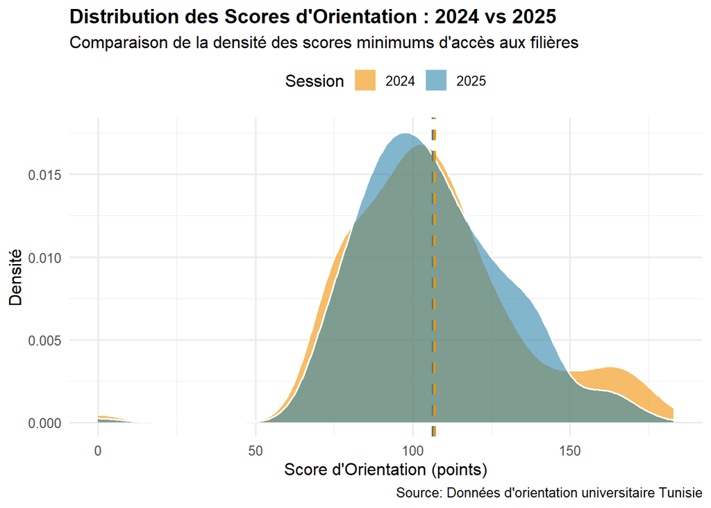

```r
# Visualisation : Comparaison des distributions 2024 vs 2025
df_long <- df %>%
  select(Filiere, Score_2025, Score_2024) %>%
  pivot_longer(cols = c(Score_2025, Score_2024),
               names_to = "Annee",
               values_to = "Score") %>%
  mutate(Annee = ifelse(Annee == "Score_2025", "2025", "2024"))

ggplot(df_long, aes(x = Score, fill = Annee)) +
  geom_density(alpha = 0.6, color = "white") +
  scale_fill_manual(values = c("2024" = "#F18F01", "2025" = "#2E86AB")) +
  labs(
    title = "Distribution des Scores d'Orientation : 2024 vs 2025",
    subtitle = "Comparaison de la densité des scores minimums d'accès aux filières",
    x = "Score d'Orientation (points)",
    y = "Densité",
    fill = "Session",
    caption = "Source: Données d'orientation universitaire Tunisie"
  ) +
  theme_minimal(base_size = 12) +
  theme(
    plot.title = element_text(face = "bold", size = 14),
    legend.position = "top"
  ) +
  geom_vline(aes(xintercept = mean(df$Score_2025, na.rm = TRUE)),
             color = "#2E86AB", linetype = "dashed", size = 1) +
  geom_vline(aes(xintercept = mean(df$Score_2024, na.rm = TRUE)),
             color = "#F18F01", linetype = "dashed", size = 1)
```

### 3.3.2 Insight 1 : Évolution des Scores

**Question** : Les scores d’orientation ont-ils baissé proportionnellement au taux de réussite du bac ?

```r
# Calcul de l'évolution des scores par filière
df <- df %>%
  mutate(
    Evolution = Score_2025 - Score_2024,
    Evolution_Pct = round((Evolution / Score_2024) * 100, 2),
    Tendance = case_when(
      Evolution < -5 ~ "Forte baisse",
      Evolution < 0 ~ "Légère baisse",
      Evolution == 0 ~ "Stable",
      Evolution < 5 ~ "Légère hausse",
      TRUE ~ "Forte hausse"
    )
  )

# Résumé des tendances
tendances_resume <- df %>%
  count(Tendance) %>%
  mutate(Pourcentage = round(n / sum(n) * 100, 1)) %>%
  arrange(desc(n))

cat("répartition des tendances 2024 -> 2025\n\n")
```

```
répartition des tendances 2024 -> 2025
```

```r
for(i in 1:nrow(tendances_resume)) {
  cat(sprintf("%-15s : %3d filières (%5.1f%%)\n",
              tendances_resume$Tendance[i],
              tendances_resume$n[i],
              tendances_resume$Pourcentage[i]))
}
```

```
Légère hausse :  74 filières ( 31.1%)
Forte baisse    :  65 filières ( 27.3%)
Forte hausse    :  48 filières ( 20.2%)
Légère baisse :  48 filières ( 20.2%)
Stable          :   3 filières (  1.3%)
```

```r
# Filières avec la plus grande baisse
cat("\n\ntop 10 filières avec la plus grande baisse de score:\n")
```

```
top 10 filières avec la plus grande baisse de score:
```

```r
df %>%
  filter(Score_2024 > 0) %>%
  arrange(Evolution) %>%
  select(Filiere, Gouvernorat, Score_2024, Score_2025, Evolution) %>%
  head(10) %>%
  print()
```

```
                                  Filiere Gouvernorat Score_2024 Score_2025
1             l en musique et musicologie      Le Kef    89.6367     0.0000
2  l en sciences maïeutiques - sage femme        Sfax   159.7243   123.6850
3                l en santé: puériculture      Sousse   164.3039   129.4219
4             l en urgence et réanimation      Sousse   169.5629   136.9814
5               l en sciences infirmieres      Sousse   169.6004   138.7683
6                               pharmacie    Monastir   167.3050   138.9550
7               l en sciences infirmieres       Gabes   163.6512   139.2980
8                l en santé: puériculture       Tunis   164.0524   139.7206
9  l en sciences maïeutiques - sage femme    Monastir   159.3498   136.6283
10                      médecine dentaire    Monastir   182.9100   162.3500
   Evolution
1   -89.6367
2   -36.0393
3   -34.8820
4   -32.5815
5   -30.8321
6   -28.3500
7   -24.3532
8   -24.3318
9   -22.7215
10  -20.5600
```

**Observation** : 47.5% des filières ont vu leur score baisser, tandis que 51.3% ont vu leur score augmenter. Cette répartition suggère que la baisse du taux de réussite n’a pas uniformément affecté toutes les filières.

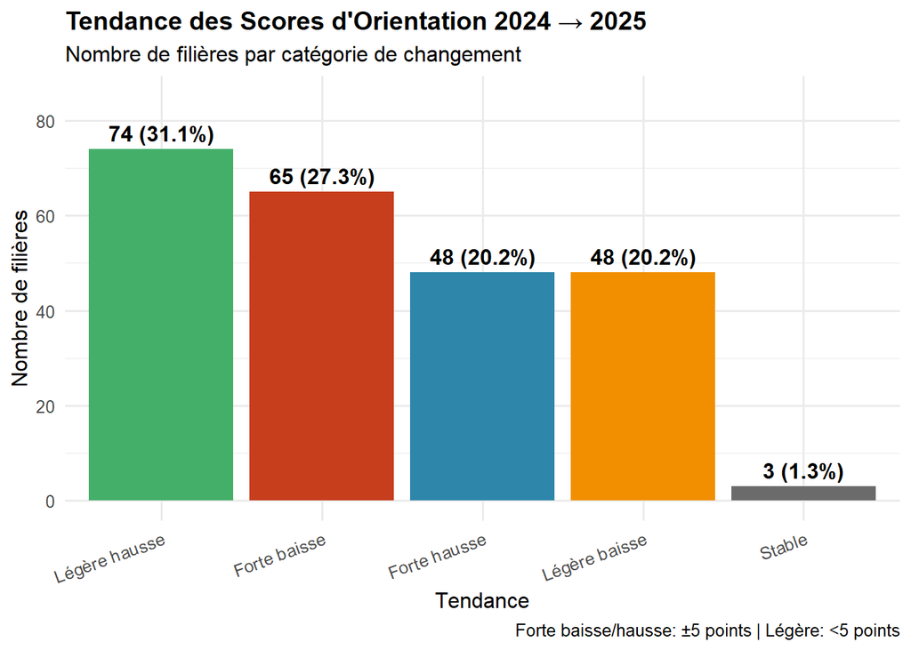

```r
# Visualisation des tendances
ggplot(tendances_resume, aes(x = reorder(Tendance, -n), y = n, fill = Tendance)) +
  geom_col(show.legend = FALSE) +
  geom_text(aes(label = paste0(n, " (", Pourcentage, "%)")),
            vjust = -0.5, fontface = "bold") +
  scale_fill_manual(values = c(
    "Forte baisse" = "#C73E1D",
    "Légère baisse" = "#F18F01",
    "Stable" = "#6B6B6B",
    "Légère hausse" = "#44AF69",
    "Forte hausse" = "#2E86AB"
  )) +
  labs(
    title = "Tendance des Scores d'Orientation 2024 → 2025",
    subtitle = "Nombre de filières par catégorie de changement",
    x = "Tendance",
    y = "Nombre de filières",
    caption = "Forte baisse/hausse: ±5 points | Légère: <5 points"
  ) +
  theme_minimal(base_size = 12) +
  theme(
    plot.title = element_text(face = "bold", size = 14),
    axis.text.x = element_text(angle = 20, hjust = 1)
  ) +
  ylim(0, max(tendances_resume$n) * 1.15)
```

## 3.4 3. Répartition Géographique des Opportunités

**Question** : Comment les filières sont-elles distribuées sur le territoire tunisien ? Les bacheliers de l’intérieur ont-ils les mêmes opportunités que ceux du Grand Tunis ?

```r
# Analyse par gouvernorat
gouvernorat_stats <- df %>%
  group_by(Gouvernorat) %>%
  summarise(
    Nb_Filieres = n(),
    Score_Moyen_2025 = round(mean(Score_2025, na.rm = TRUE), 2),
    Score_Min_2025 = round(min(Score_2025, na.rm = TRUE), 2),
    Score_Max_2025 = round(max(Score_2025, na.rm = TRUE), 2),
    Nb_Universites = n_distinct(Universite),
    Nb_Etablissements = n_distinct(Etablissement)
  ) %>%
  arrange(desc(Nb_Filieres))

cat("répartition par gouvernorat\n\n")
```

```
répartition par gouvernorat
```

```r
# Calcul des pourcentages
total_filieres <- sum(gouvernorat_stats$Nb_Filieres)
gouvernorat_stats <- gouvernorat_stats %>%
  mutate(Pourcentage = round(Nb_Filieres / total_filieres * 100, 1))

print(gouvernorat_stats)
```

```
# A tibble: 19 × 8
   Gouvernorat Nb_Filieres Score_Moyen_2025 Score_Min_2025 Score_Max_2025
   <chr>             <int>            <dbl>          <dbl>          <dbl>
 1 Tunis                89            107.            68.2          166.
 2 Sfax                 25            108.            72.0          160.
 3 Sousse               18            114.            73.5          166.
 4 Gabes                16            105.            78.0          139.
 5 Monastir             13            120.            70.9          164.
 6 Kairouan             12             89.4           70.2          112.
 7 Gafsa                11            109.            74.1          142.
 8 Le Kef                8            101.             0            173.
 9 Nabeul                8            101.            69.9          130.
10 Jendouba              6             91.9           67.5          127.
11 Kasserine             6            102.            72.1          127.
12 Mednine               5             94.4           77.2          126.
13 Sidi Bouzid           5            108.            95.0          118.
14 Tataouine             5            105.            80.1          125.
15 Mahdia                4            119.           106.           138.
16 Siliana               3             97.1           76.2          112.
17 Tozeur                2            102.            78.2          126.
18 Beja                  1             80.1           80.1           80.1
19 Zaghouane             1            129.           129.           129.
# ℹ 3 more variables: Nb_Universites <int>, Nb_Etablissements <int>,
#   Pourcentage <dbl>
```

```r
cat("\n\nconcentration géographique:\n")
```

```
concentration géographique:
```

```r
tunis_pct <- sum(gouvernorat_stats$Pourcentage[gouvernorat_stats$Gouvernorat == "Tunis"])
cat("grand tunis concentre:", tunis_pct, "% des filières\n")
```

```
grand tunis concentre: 37.4 % des filières
```

```r
cat("nombre de gouvernorats avec des filières:", nrow(gouvernorat_stats), "\n")
```

```
nombre de gouvernorats avec des filières: 19
```

**Observation** : Tunis concentre 37.4% des filières, suivie par Sfax (10.5%) et Sousse (7.6%). Cette concentration géographique crée une inégalité d’accès pour les étudiants des régions intérieures.

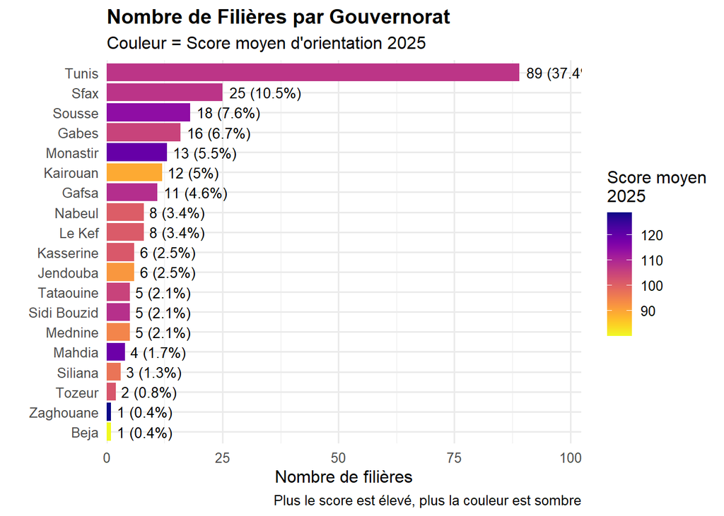

```r
# Visualisation : Répartition par gouvernorat
ggplot(gouvernorat_stats, aes(x = reorder(Gouvernorat, Nb_Filieres), y = Nb_Filieres, fill = Score_Moyen_2025)) +
  geom_col() +
  geom_text(aes(label = paste0(Nb_Filieres, " (", Pourcentage, "%)")),
            hjust = -0.1, size = 3.5) +
  coord_flip() +
  scale_fill_viridis(option = "plasma", direction = -1, name = "Score moyen\n2025") +
  labs(
    title = "Nombre de Filières par Gouvernorat",
    subtitle = "Couleur = Score moyen d'orientation 2025",
    x = "",
    y = "Nombre de filières",
    caption = "Plus le score est élevé, plus la couleur est sombre"
  ) +
  theme_minimal(base_size = 12) +
  theme(
    plot.title = element_text(face = "bold", size = 14),
    legend.position = "right"
  ) +
  scale_y_continuous(expand = expansion(mult = c(0, 0.15)))
```

**Conclusion** : La polarisation géographique est marquée. Les étudiants du Grand Tunis ont accès à près de 40% de l’offre, tandis que certains gouvernorats n’offrent qu’une ou deux filières.

## 3.5 4. Analyse par Université

**Question** : Quelles universités offrent le plus d’opportunités aux bacheliers lettres ?

```r
# Analyse par université
universite_stats <- df %>%
  group_by(Universite) %>%
  summarise(
    Nb_Filieres = n(),
    Nb_Etablissements = n_distinct(Etablissement),
    Score_Moyen_2025 = round(mean(Score_2025, na.rm = TRUE), 2),
    Score_Min = round(min(Score_2025, na.rm = TRUE), 2),
    Score_Max = round(max(Score_2025, na.rm = TRUE), 2),
    Ecart_Score = Score_Max - Score_Min
  ) %>%
  arrange(desc(Nb_Filieres)) %>%
  mutate(
    Universite_Clean = str_to_title(str_replace_all(Universite, "\\s+", " ")),
    Pourcentage = round(Nb_Filieres / sum(Nb_Filieres) * 100, 1)
  )

cat("répartition par université\n\n")
```

```
répartition par université
```

```r
for(i in 1:nrow(universite_stats)) {
  cat(sprintf("%d. %-35s: %2d filières (%4.1f%%) | score: %5.1f - %5.1f\n",
              i,
              substr(universite_stats$Universite_Clean[i], 1, 35),
              universite_stats$Nb_Filieres[i],
              universite_stats$Pourcentage[i],
              universite_stats$Score_Min[i],
              universite_stats$Score_Max[i]))
}
```

```
1. Universite De Carthage             : 26 filières (10.9%) | score:  69.9 - 158.3
2. Universite De Gabes                : 26 filières (10.9%) | score:  77.2 - 139.3
3. Universite Du Sfax                 : 25 filières (10.5%) | score:  72.0 - 159.8
4. Universite De Tunis                : 23 filières ( 9.7%) | score:  68.2 - 144.5
5. Universite De Manouba              : 23 filières ( 9.7%) | score:  75.7 - 141.8
6. Universite De Tunis El Manar       : 23 filières ( 9.7%) | score:  69.5 - 166.3
7. Universite De Kairouan             : 22 filières ( 9.2%) | score:  70.2 - 126.7
8. Universite De Jendouba             : 18 filières ( 7.6%) | score:   0.0 - 173.2
9. Universite Du Sousse               : 18 filières ( 7.6%) | score:  73.5 - 165.8
10. Universite De Monastir             : 17 filières ( 7.1%) | score:  70.9 - 164.5
11. Universite De Gafsa                : 13 filières ( 5.5%) | score:  74.1 - 141.7
12. Universite Ez-Zitouna              :  4 filières ( 1.7%) | score:  95.4 - 104.6
```

**Observation** : Les universités de Carthage, Gabès et Sfax offrent chacune environ 10-11% des filières, suivies de près par Tunis, Manouba et Tunis El Manar.

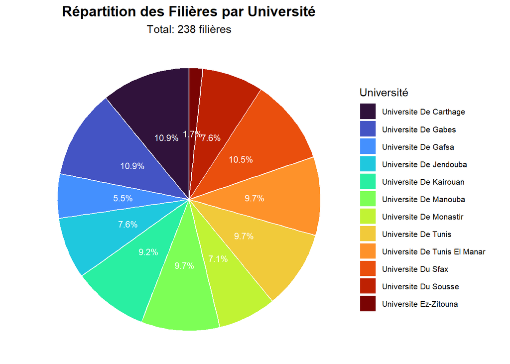

```r
# Visualisation : Répartition par université (camembert)
ggplot(universite_stats, aes(x = "", y = Nb_Filieres, fill = Universite_Clean)) +
  geom_bar(stat = "identity", width = 1, color = "white") +
  coord_polar("y", start = 0) +
  scale_fill_viridis(discrete = TRUE, option = "turbo") +
  labs(
    title = "Répartition des Filières par Université",
    subtitle = paste0("Total: ", sum(universite_stats$Nb_Filieres), " filières"),
    fill = "Université"
  ) +
  theme_void() +
  theme(
    plot.title = element_text(face = "bold", size = 14, hjust = 0.5),
    plot.subtitle = element_text(hjust = 0.5),
    legend.position = "right",
    legend.text = element_text(size = 8)
  ) +
  geom_text(aes(label = paste0(Pourcentage, "%")),
            position = position_stack(vjust = 0.5), size = 3, color = "white")
```

## 3.6 5. Analyse des Types de Filières

**Question** : Quels domaines d’études sont les plus représentés ? Quelles sont les filières les plus accessibles vs les plus sélectives ?

```r
# Catégorisation des filières par domaine
df <- df %>%
  mutate(Domaine = case_when(
    str_detect(Filiere, "médecine|infirm|santé|physio|ortho|sage|puér|urgence|hygiene") ~ "Sante",
    str_detect(Filiere, "droit|juridique|social|travail") ~ "Droit & Social",
    str_detect(Filiere, "arabe|français|anglais|espagnol|italien|allemand|russe|chinois|langue") ~ "Langues",
    str_detect(Filiere, "arts|design|musique|théâ|cinéma|beaux|plastique") ~ "Arts & Design",
    str_detect(Filiere, "histoire|géo|archéo|patrimoine|anthropo|socio|philo|psycho") ~ "Sciences Humaines",
    str_detect(Filiere, "éducation|enseignement|cadre") ~ "Education",
    str_detect(Filiere, "journal|communication|document|média") ~ "Communication",
    str_detect(Filiere, "tourism|hôtel") ~ "Tourisme",
    str_detect(Filiere, "sport|physique") ~ "Sport",
    str_detect(Filiere, "islam|théolog|zitouna") ~ "Sciences Islamiques",
    str_detect(Filiere, "prépa|cycle") ~ "Classes Preparatoires",
    str_detect(Filiere, "architect|urban") ~ "Architecture",
    str_detect(Filiere, "traduction") ~ "Traduction",
    TRUE ~ "Autres"
  ))

# Statistiques par domaine
domaine_stats <- df %>%
  group_by(Domaine) %>%
  summarise(
    Nb_Filieres = n(),
    Score_Moyen = round(mean(Score_2025, na.rm = TRUE), 2),
    Score_Min = round(min(Score_2025, na.rm = TRUE), 2),
    Score_Max = round(max(Score_2025, na.rm = TRUE), 2),
    Evolution_Moy = round(mean(Evolution, na.rm = TRUE), 2)
  ) %>%
  arrange(desc(Nb_Filieres)) %>%
  mutate(Pourcentage = round(Nb_Filieres / sum(Nb_Filieres) * 100, 1))

cat("répartition par domaine d'études\n\n")
```

```
répartition par domaine d'études
```

```r
# Affichage formaté du tableau
domaine_stats_display <- domaine_stats %>%
  rename(
    "Domaine" = "Domaine",
    "Filières" = "Nb_Filieres",
    "Score Moy" = "Score_Moyen",
    "Score Min" = "Score_Min",
    "Score Max" = "Score_Max",
    "Évolution" = "Evolution_Moy",
    "%" = "Pourcentage"
  ) %>%
  mutate(across(where(is.numeric), ~round(., 1)))

knitr::kable(domaine_stats_display,
             format = "simple",
             digits = 1,
             caption = "Statistiques par Domaine d'Études")
```

Statistiques par Domaine d’Études

| Domaine | Filières | Score Moy | Score Min | Score Max | Évolution | % |
| --- | --- | --- | --- | --- | --- | --- |
| Langues | 70 | 90.6 | 67.5 | 144.5 | -1.4 | 29.4 |
| Arts & Design | 56 | 103.6 | 0.0 | 138.5 | -0.5 | 23.5 |
| Sante | 29 | 142.8 | 88.2 | 173.2 | -2.4 | 12.2 |
| Sciences Humaines | 29 | 96.9 | 79.2 | 138.2 | 2.4 | 12.2 |
| Autres | 14 | 111.5 | 76.4 | 139.0 | -0.2 | 5.9 |
| Droit & Social | 11 | 111.8 | 100.9 | 139.6 | -0.6 | 4.6 |
| Education | 11 | 127.5 | 119.1 | 138.3 | 7.1 | 4.6 |
| Communication | 4 | 100.3 | 96.5 | 105.5 | -1.4 | 1.7 |
| Sport | 4 | 138.7 | 137.0 | 141.8 | -8.2 | 1.7 |
| Sciences Islamiques | 3 | 100.4 | 95.4 | 104.6 | 1.0 | 1.3 |
| Traduction | 3 | 92.0 | 77.3 | 103.3 | -2.4 | 1.3 |
| Architecture | 2 | 140.0 | 121.8 | 158.3 | -2.6 | 0.8 |
| Tourisme | 2 | 111.8 | 111.3 | 112.3 | 3.1 | 0.8 |

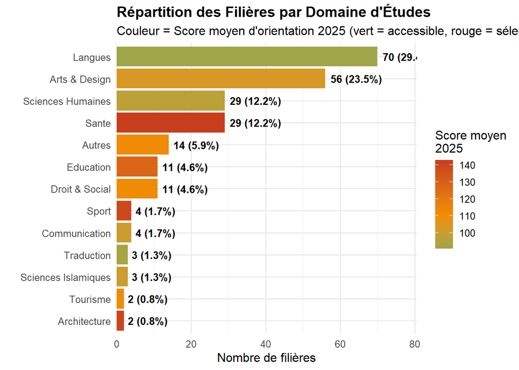

```r
# Visualisation : Nombre de filières par domaine avec scores
ggplot(domaine_stats, aes(x = reorder(Domaine, Nb_Filieres), y = Nb_Filieres, fill = Score_Moyen)) +
  geom_col() +
  geom_text(aes(label = paste0(Nb_Filieres, " (", Pourcentage, "%)")),
            hjust = -0.1, size = 3.5, fontface = "bold") +
  coord_flip() +
  scale_fill_gradient2(low = "#44AF69", mid = "#F18F01", high = "#C73E1D",
                       midpoint = 110, name = "Score moyen\n2025") +
  labs(
    title = "Répartition des Filières par Domaine d'Études",
    subtitle = "Couleur = Score moyen d'orientation 2025 (vert = accessible, rouge = sélectif)",
    x = "",
    y = "Nombre de filières"
  ) +
  theme_minimal(base_size = 12) +
  theme(
    plot.title = element_text(face = "bold", size = 14),
    legend.position = "right"
  ) +
  scale_y_continuous(expand = expansion(mult = c(0, 0.15)))
```

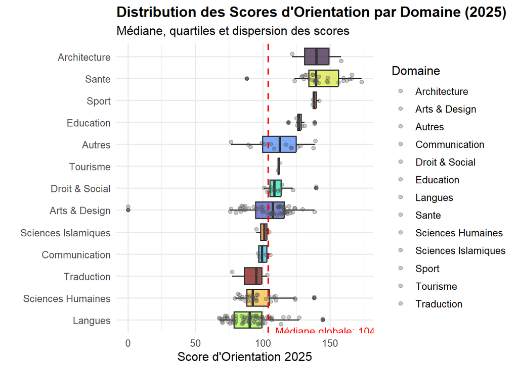

```r
# Boxplot : Distribution des scores par domaine
ggplot(df, aes(x = reorder(Domaine, Score_2025, FUN = median), y = Score_2025, fill = Domaine)) +
  geom_boxplot(alpha = 0.7, show.legend = FALSE) +
  geom_jitter(width = 0.2, alpha = 0.3, size = 1.5, color = "gray30") +
  coord_flip() +
  scale_fill_viridis(discrete = TRUE, option = "turbo") +
  labs(
    title = "Distribution des Scores d'Orientation par Domaine (2025)",
    subtitle = "Médiane, quartiles et dispersion des scores",
    x = "",
    y = "Score d'Orientation 2025"
  ) +
  theme_minimal(base_size = 12) +
  theme(
    plot.title = element_text(face = "bold", size = 14)
  ) +
  geom_hline(yintercept = median(df$Score_2025, na.rm = TRUE),
             linetype = "dashed", color = "red", size = 0.8) +
  annotate("text", x = 0.5, y = median(df$Score_2025, na.rm = TRUE) + 5,
           label = paste0("Médiane globale: ", round(median(df$Score_2025, na.rm = TRUE), 1)),
           color = "red", hjust = 0, size = 3.5)
```

## 3.7 6. Analyse des Conditions d’Admission

**Question** : Quelles contraintes spécifiques (sport, SVT, langues, âge, sexe) limitent l’accès aux filières ?

```r
# Analyse des conditions d'admission
conditions_stats <- df %>%
  group_by(Conditions) %>%
  summarise(
    Nb_Filieres = n(),
    Score_Moyen = round(mean(Score_2025, na.rm = TRUE), 2),
    Domaines = paste(unique(Domaine), collapse = ", ")
  ) %>%
  arrange(desc(Nb_Filieres)) %>%
  mutate(Pourcentage = round(Nb_Filieres / sum(Nb_Filieres) * 100, 1))

cat("conditions d'admission\n\n")
```

```
conditions d'admission
```

```r
for(i in 1:nrow(conditions_stats)) {
  cat(sprintf("%-45s : %2d filières (%5.1f%%) | score moy: %6.2f\n",
              conditions_stats$Conditions[i],
              conditions_stats$Nb_Filieres[i],
              conditions_stats$Pourcentage[i],
              conditions_stats$Score_Moyen[i]))
}
```

```
aucune                                        : 163 filières ( 68.5%) | score moy:  98.93
âge limite                                   : 19 filières (  8.0%) | score moy: 116.99
svt obligatoire                               : 15 filières (  6.3%) | score moy: 141.17
langue obligatoire : allemand                 :  6 filières (  2.5%) | score moy:  92.52
langue obligatoire : italien                  :  6 filières (  2.5%) | score moy:  96.84
langue obligatoire : espagnol                 :  5 filières (  2.1%) | score moy:  90.58
svt et sport obligatoires, sexe féminin      :  5 filières (  2.1%) | score moy: 151.10
svt et sport obligatoires, sexe masculin      :  5 filières (  2.1%) | score moy: 141.69
sport obligatoire >=16                        :  4 filières (  1.7%) | score moy: 138.73
sport obligatoire                             :  3 filières (  1.3%) | score moy: 111.63
svt et sport obligatoires                     :  3 filières (  1.3%) | score moy: 142.31
svt obligatoire, sexe féminin                :  3 filières (  1.3%) | score moy: 132.90
svt et sport obligatoires, non-voyant         :  1 filières (  0.4%) | score moy:  88.24
```

```r
# Calcul des filières sans contraintes
sans_contraintes <- sum(conditions_stats$Nb_Filieres[conditions_stats$Conditions == "aucune"])
avec_contraintes <- sum(conditions_stats$Nb_Filieres) - sans_contraintes

cat("\n\nrésumé:\n")
```

```
résumé:
```

```r
cat("filières sans contraintes:", sans_contraintes, "(", round(sans_contraintes/sum(conditions_stats$Nb_Filieres)*100, 1), "%)\n")
```

```
filières sans contraintes: 163 ( 68.5 %)
```

```r
cat("filières avec contraintes:", avec_contraintes, "(", round(avec_contraintes/sum(conditions_stats$Nb_Filieres)*100, 1), "%)\n")
```

```
filières avec contraintes: 75 ( 31.5 %)
```

**Observation** : 68.5% des filières n’ont aucune contrainte particulière. Les contraintes les plus fréquentes sont l’âge limite (8.0%), SVT obligatoire (6.3%), et les langues étrangères (7.1%).

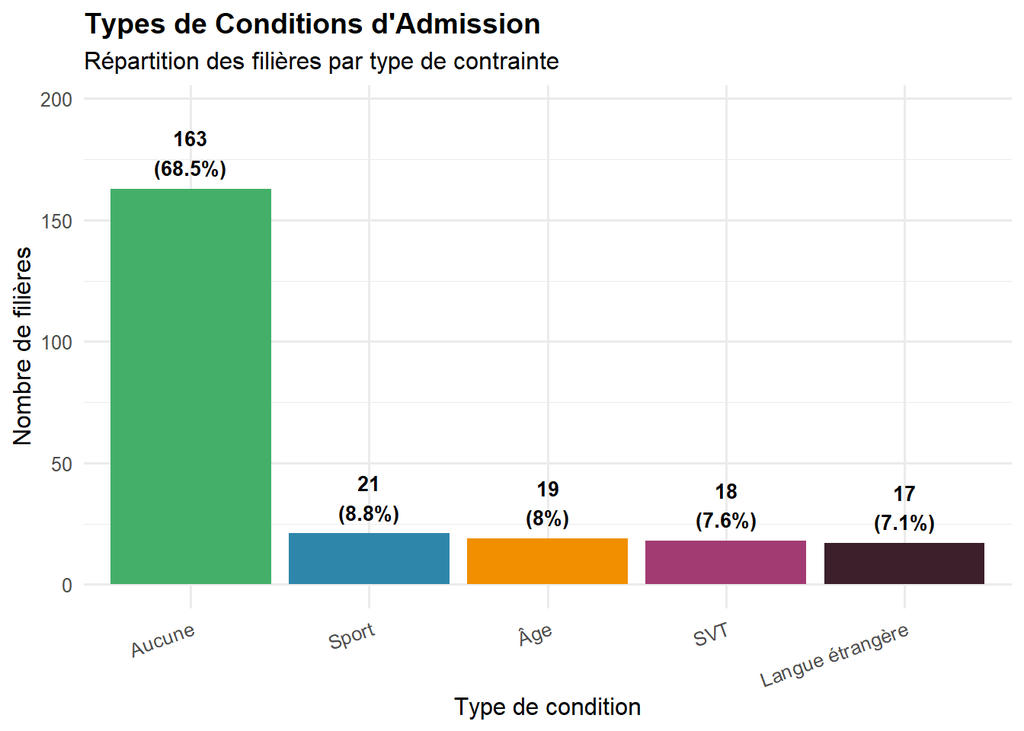

```r
# Visualisation des conditions
conditions_stats_filtered <- conditions_stats %>%
  mutate(Type_Condition = case_when(
    Conditions == "aucune" ~ "Aucune",
    str_detect(Conditions, "sport") ~ "Sport",
    str_detect(Conditions, "svt") ~ "SVT",
    str_detect(Conditions, "âge|age") ~ "Âge",
    str_detect(Conditions, "langue") ~ "Langue étrangère",
    str_detect(Conditions, "sexe") ~ "Sexe spécifique",
    TRUE ~ "Autre"
  ))

type_condition_stats <- conditions_stats_filtered %>%
  group_by(Type_Condition) %>%
  summarise(
    Nb_Total = sum(Nb_Filieres),
    Score_Moyen = round(mean(Score_Moyen), 2)
  ) %>%
  mutate(Pourcentage = round(Nb_Total / sum(Nb_Total) * 100, 1))

ggplot(type_condition_stats, aes(x = reorder(Type_Condition, -Nb_Total), y = Nb_Total, fill = Type_Condition)) +
  geom_col(show.legend = FALSE) +
  geom_text(aes(label = paste0(Nb_Total, "\n(", Pourcentage, "%)")),
            vjust = -0.3, fontface = "bold", size = 3.5) +
  scale_fill_manual(values = c(
    "Aucune" = "#44AF69",
    "Âge" = "#F18F01",
    "Sport" = "#2E86AB",
    "SVT" = "#A23B72",
    "Langue étrangère" = "#3B1F2B",
    "Sexe spécifique" = "#C73E1D",
    "Autre" = "#6B6B6B"
  )) +
  labs(
    title = "Types de Conditions d'Admission",
    subtitle = "Répartition des filières par type de contrainte",
    x = "Type de condition",
    y = "Nombre de filières"
  ) +
  theme_minimal(base_size = 12) +
  theme(
    plot.title = element_text(face = "bold", size = 14),
    axis.text.x = element_text(angle = 20, hjust = 1)
  ) +
  ylim(0, max(type_condition_stats$Nb_Total) * 1.2)
```

**Conclusion** : Près d’un tiers des filières (31.5%) imposent des contraintes qui peuvent limiter l’accès, notamment dans les domaines de la Santé et du Sport.

## 3.8 7. Analyse de la Durée des Études

**Question** : Quelle est la répartition des durées d’études et quel est l’investissement en temps requis par domaine ?

```r
# Analyse de la durée des études
duree_stats <- df %>%
  group_by(Duree) %>%
  summarise(
    Nb_Filieres = n(),
    Score_Moyen = round(mean(Score_2025, na.rm = TRUE), 2),
    Domaines = paste(unique(Domaine), collapse = ", ")
  ) %>%
  arrange(Duree) %>%
  mutate(Pourcentage = round(Nb_Filieres / sum(Nb_Filieres) * 100, 1))

cat("durée des études\n\n")
```

```
durée des études
```

```r
for(i in 1:nrow(duree_stats)) {
  cat(sprintf("%-10s : %3d filières (%5.1f%%) | score moy: %6.2f\n",
              duree_stats$Duree[i],
              duree_stats$Nb_Filieres[i],
              duree_stats$Pourcentage[i],
              duree_stats$Score_Moyen[i]))
}
```

```
02 ans     :   9 filières (  3.8%) | score moy: 104.34
03 ans     : 222 filières ( 93.3%) | score moy: 104.81
06 ans     :   3 filières (  1.3%) | score moy: 153.20
09 ans     :   4 filières (  1.7%) | score moy: 164.11
```

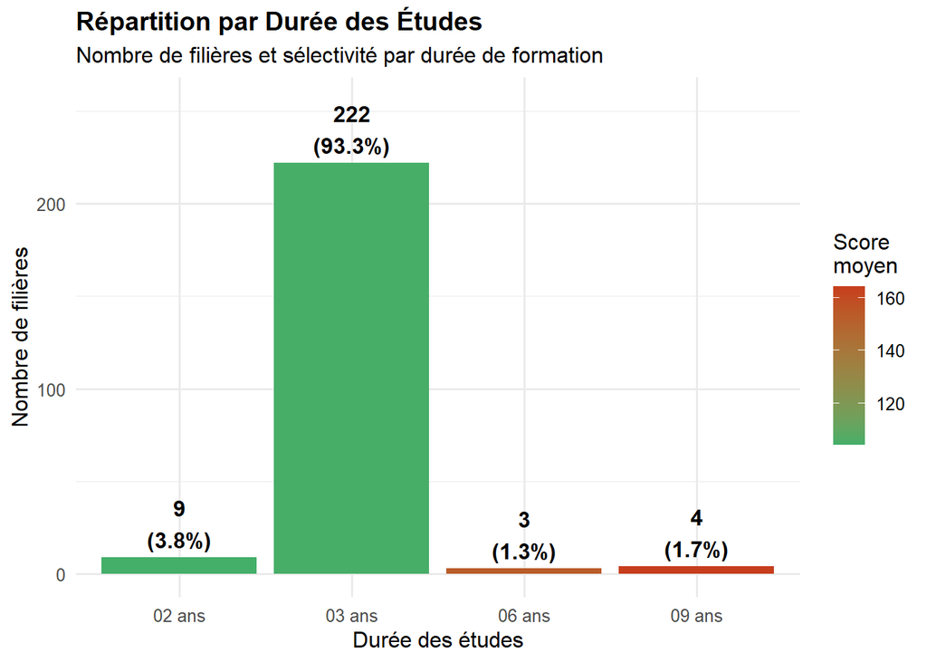

```r
# Visualisation
ggplot(duree_stats, aes(x = Duree, y = Nb_Filieres, fill = Score_Moyen)) +
  geom_col() +
  geom_text(aes(label = paste0(Nb_Filieres, "\n(", Pourcentage, "%)")),
            vjust = -0.2, fontface = "bold") +
  scale_fill_gradient(low = "#44AF69", high = "#C73E1D", name = "Score\nmoyen") +
  labs(
    title = "Répartition par Durée des Études",
    subtitle = "Nombre de filières et sélectivité par durée de formation",
    x = "Durée des études",
    y = "Nombre de filières"
  ) +
  theme_minimal(base_size = 12) +
  theme(
    plot.title = element_text(face = "bold", size = 14)
  ) +
  ylim(0, max(duree_stats$Nb_Filieres) * 1.15)
```

**Observation** : 93.3% des filières durent 3 ans. Les filières de 6 et 9 ans (Médecine, Pharmacie, Médecine Dentaire) sont les plus sélectives avec des scores moyens supérieurs à 150 points.

## 3.9 8. Top Filières : Les Plus et Moins Sélectives

**Question** : Quelles sont les filières les plus accessibles et les plus sélectives pour un bachelier lettres en 2025 ?

```r
# Top 15 filières les plus sélectives (score le plus élevé)
cat("top 15 filières les plus sélectives (score 2025)\n\n")
```

```
top 15 filières les plus sélectives (score 2025)
```

```r
top_selectives <- df %>%
  arrange(desc(Score_2025)) %>%
  select(Filiere, Gouvernorat, Score_2025, Score_2024, Domaine) %>%
  head(15)

for(i in 1:nrow(top_selectives)) {
  cat(sprintf("%2d. %-45s | %s | score: %6.2f\n",
              i,
              substr(str_to_title(top_selectives$Filiere[i]), 1, 45),
              top_selectives$Gouvernorat[i],
              top_selectives$Score_2025[i]))
}
```

```
 1. L En Sciences Infirmieres                     | Le Kef | score: 173.22
 2. Médecine                                     | Tunis | score: 166.34
 3. Médecine                                     | Sousse | score: 165.79
 4. Médecine                                     | Monastir | score: 164.46
 5. Médecine Dentaire                            | Monastir | score: 162.35
 6. Médecine                                     | Sfax | score: 159.85
 7. L En Sciences Infirmieres                     | Tunis | score: 159.80
 8. Architecture                                  | Tunis | score: 158.29
 9. L En Sciences Infirmieres                     | Tunis | score: 156.15
10. L En Santé: Physiothérapie                  | Sfax | score: 148.09
11. L En Sciences Infirmieres                     | Sfax | score: 148.07
12. L En Santé: Physiothérapie                  | Monastir | score: 147.53
13. Prépa-Lettre Spécialité Anglais            | Tunis | score: 144.54
14. L En Sciences Physiques Et Sportives          | Tunis | score: 141.78
15. L En Urgence Et Réanimation                  | Gafsa | score: 141.70
```

```r
cat("\n\ntop 15 filières les plus accessibles (score 2025)\n\n")
```

```
top 15 filières les plus accessibles (score 2025)
```

```r
top_accessibles <- df %>%
  arrange(Score_2025) %>%
  filter(Score_2025 > 0) %>%
  select(Filiere, Gouvernorat, Score_2025, Score_2024, Domaine) %>%
  head(15)

for(i in 1:nrow(top_accessibles)) {
  cat(sprintf("%2d. %-45s | %s | score: %6.2f\n",
              i,
              substr(str_to_title(top_accessibles$Filiere[i]), 1, 45),
              top_accessibles$Gouvernorat[i],
              top_accessibles$Score_2025[i]))
}
```

```
 1. L En Français                                | Jendouba | score:  67.53
 2. L En Français                                | Tunis | score:  68.22
 3. L En Français                                | Tunis | score:  69.47
 4. L En Français                                | Nabeul | score:  69.93
 5. L En Anglais                                  | Kairouan | score:  70.18
 6. L En Français                                | Monastir | score:  70.90
 7. L En Français                                | Sfax | score:  71.97
 8. L En Anglais                                  | Kasserine | score:  72.11
 9. L En Français                                | Sousse | score:  73.47
10. L En Français                                | Tunis | score:  73.52
11. L En Anglais                                  | Gafsa | score:  74.06
12. L En Français                                | Kairouan | score:  74.28
13. L En Français                                | Tunis | score:  75.65
14. L En Arts Plastiques                          | Kairouan | score:  75.82
15. L En Arts Plastiques                          | Siliana | score:  76.24
```

[figure not shown]

```r
# Visualisation comparative Top 10 sélectives vs accessibles
top10_comparison <- rbind(
  top_selectives %>% head(10) %>% mutate(Categorie = "Plus Sélectives"),
  top_accessibles %>% head(10) %>% mutate(Categorie = "Plus Accessibles")
)

ggplot(top10_comparison, aes(x = reorder(paste0(substr(str_to_title(Filiere), 1, 30), "..."), Score_2025),
                             y = Score_2025, fill = Categorie)) +
  geom_col() +
  geom_text(aes(label = round(Score_2025, 1)), hjust = -0.1, size = 3) +
  coord_flip() +
  facet_wrap(~Categorie, scales = "free_y") +
  scale_fill_manual(values = c("Plus Sélectives" = "#C73E1D", "Plus Accessibles" = "#44AF69")) +
  labs(
    title = "Comparaison : Filières les Plus et Moins Sélectives (2025)",
    subtitle = "Top 10 de chaque catégorie",
    x = "",
    y = "Score d'Orientation 2025"
  ) +
  theme_minimal(base_size = 11) +
  theme(
    plot.title = element_text(face = "bold", size = 14),
    legend.position = "none",
    strip.text = element_text(face = "bold", size = 12)
  )
```

## 3.10 9. Analyse des Critères d’Orientation

**Question** : Quels sont les critères de calcul des scores et comment impactent-ils l’orientation ?

```r
# Analyse des critères d'orientation
criteres_stats <- df %>%
  group_by(Criteres) %>%
  summarise(
    Nb_Filieres = n(),
    Score_Moyen = round(mean(Score_2025, na.rm = TRUE), 2)
  ) %>%
  arrange(desc(Nb_Filieres)) %>%
  mutate(Pourcentage = round(Nb_Filieres / sum(Nb_Filieres) * 100, 1))

cat("critères d'orientation\n\n")
```

```
critères d'orientation
```

```r
cat("FG = formation générale (score bac)\n")
```

```
FG = formation générale (score bac)
```

```r
cat("AR = arabe | F = français | ANG = anglais | HG = histoire-géo\n")
```

```
AR = arabe | F = français | ANG = anglais | HG = histoire-géo
```

```r
cat("PH = philosophie | SVT = sciences de la vie | SPT = sport\n\n")
```

```
PH = philosophie | SVT = sciences de la vie | SPT = sport
```

```r
print(criteres_stats)
```

```
# A tibble: 26 × 4
   Criteres        Nb_Filieres Score_Moyen Pourcentage
   <chr>                 <int>       <dbl>       <dbl>
 1 FG+PH                    65       105.         27.3
 2 FG+SVT                   33       141.         13.9
 3 FG+(AR+FR)/2             19       121.          8
 4 FG+ANG                   16        91.0         6.7
 5 FG+F                     15        74.5         6.3
 6 FG+(F+HG)/2              14        87.1         5.9
 7 FG+AR                    14        97.4         5.9
 8 FG+(HG+PH)/2              8       106.          3.4
 9 FG+(AR+ANG+F)/3           7        94.3         2.9
10 FG+IT                     7        96.0         2.9
# ℹ 16 more rows
```

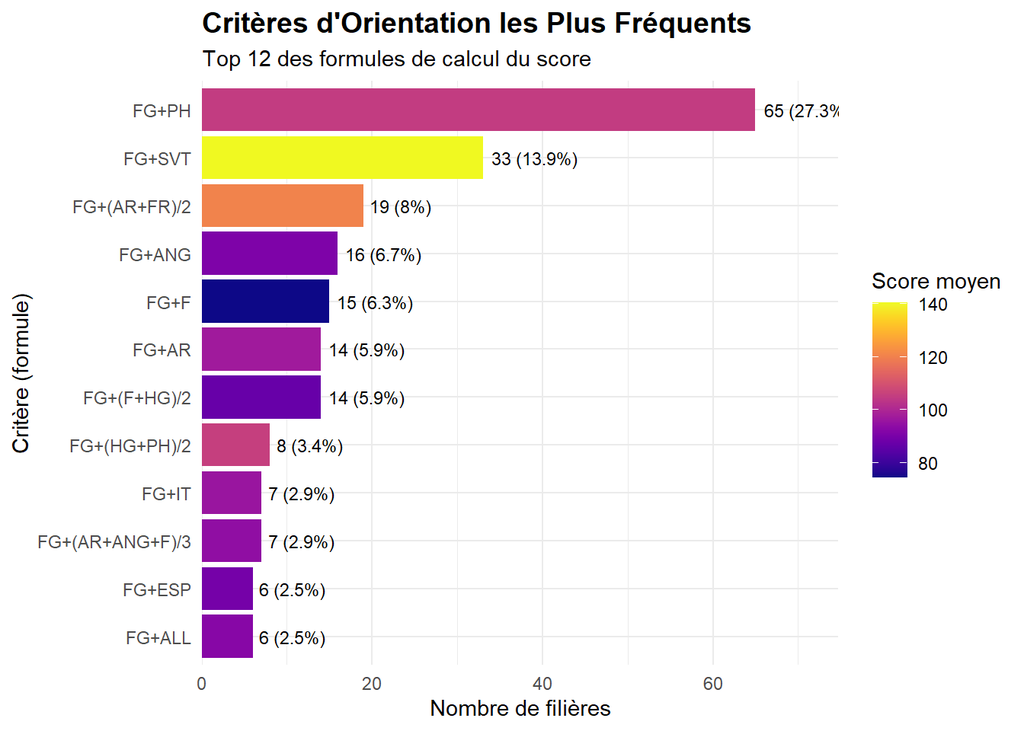

```r
# Top 10 critères les plus fréquents
ggplot(criteres_stats %>% head(12), aes(x = reorder(Criteres, Nb_Filieres), y = Nb_Filieres, fill = Score_Moyen)) +
  geom_col() +
  geom_text(aes(label = paste0(Nb_Filieres, " (", Pourcentage, "%)")),
            hjust = -0.1, size = 3) +
  coord_flip() +
  scale_fill_viridis(option = "plasma", name = "Score moyen") +
  labs(
    title = "Critères d'Orientation les Plus Fréquents",
    subtitle = "Top 12 des formules de calcul du score",
    x = "Critère (formule)",
    y = "Nombre de filières"
  ) +
  theme_minimal(base_size = 11) +
  theme(
    plot.title = element_text(face = "bold", size = 14)
  ) +
  scale_y_continuous(expand = expansion(mult = c(0, 0.15)))
```

**Observation** : Le critère le plus fréquent est “FG+PH” (27.3% des filières), suivi de “FG+SVT” (13.9%). Les critères incluant SVT sont associés aux scores moyens les plus élevés (filières de Santé).

## 3.11 10. Corrélation entre Scores 2024 et 2025

**Question** : Y a-t-il une corrélation forte entre les scores des deux années ? Les filières conservent-elles leur niveau de sélectivité ?

```r
# Corrélation entre les scores 2024 et 2025
df_corr <- df %>% filter(Score_2024 > 0)  # Exclure les nouvelles filières

correlation <- cor(df_corr$Score_2024, df_corr$Score_2025, use = "complete.obs")

cat("analyse de corrélation 2024 - 2025\n\n")
```

```
analyse de corrélation 2024 - 2025
```

```r
cat("coefficient de corrélation (pearson):", round(correlation, 4), "\n")
```

```
coefficient de corrélation (pearson): 0.8997
```

```r
cat("interprétation:", ifelse(correlation > 0.8, "corrélation forte",
                               ifelse(correlation > 0.5, "corrélation modérée", "corrélation faible")), "\n\n")
```

```
interprétation: corrélation forte
```

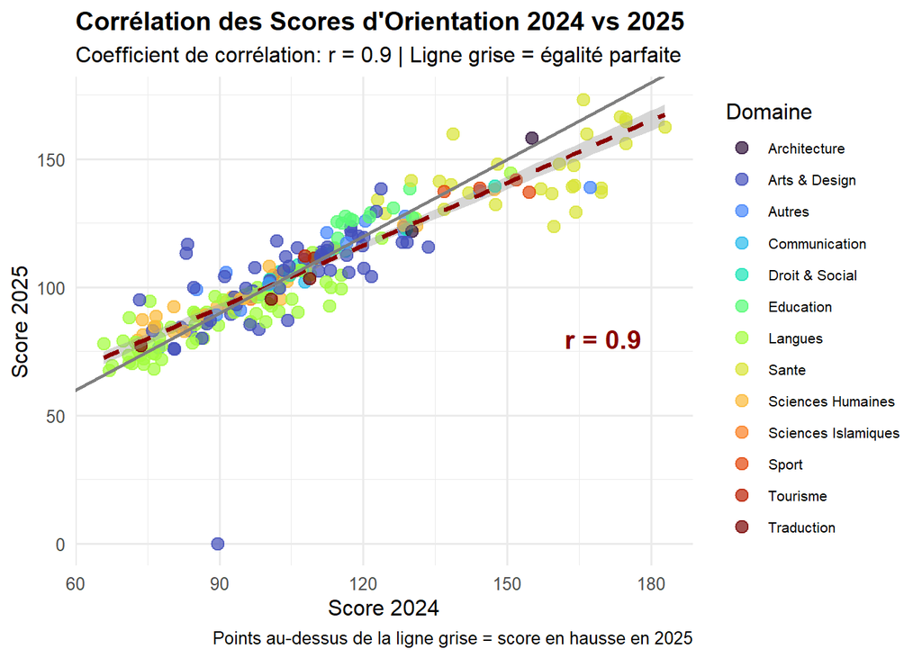

```r
# Scatter plot avec régression
ggplot(df_corr, aes(x = Score_2024, y = Score_2025, color = Domaine)) +
  geom_point(alpha = 0.7, size = 3) +
  geom_smooth(method = "lm", se = TRUE, color = "darkred", linetype = "dashed") +
  geom_abline(intercept = 0, slope = 1, linetype = "solid", color = "gray50", size = 0.8) +
  scale_color_viridis(discrete = TRUE, option = "turbo") +
  labs(
    title = "Corrélation des Scores d'Orientation 2024 vs 2025",
    subtitle = paste0("Coefficient de corrélation: r = ", round(correlation, 3),
                      " | Ligne grise = égalité parfaite"),
    x = "Score 2024",
    y = "Score 2025",
    caption = "Points au-dessus de la ligne grise = score en hausse en 2025"
  ) +
  theme_minimal(base_size = 12) +
  theme(
    plot.title = element_text(face = "bold", size = 14),
    legend.position = "right",
    legend.text = element_text(size = 8)
  ) +
  annotate("text", x = 170, y = 80, label = paste0("r = ", round(correlation, 3)),
           size = 5, fontface = "bold", color = "darkred")
```

**Observation** : La corrélation de 0.90 indique une corrélation FORTE entre les scores 2024 et 2025. Les filières conservent globalement leur niveau de sélectivité relatif, même si certaines ont connu des variations significatives.

## 3.12 11. Focus : Filières avec Évolution Remarquable

**Question** : Quelles filières ont connu les changements les plus significatifs entre 2024 et 2025 ?

```r
# Filières avec les plus grands changements
df_evolution <- df %>%
  filter(Score_2024 > 0) %>%
  mutate(
    Evolution_Abs = abs(Evolution),
    Direction = ifelse(Evolution > 0, "Hausse", "Baisse")
  ) %>%
  arrange(desc(Evolution_Abs))

cat("top 10 plus grandes baisses\n")
```

```
top 10 plus grandes baisses
```

```r
df_evolution %>%
  filter(Evolution < 0) %>%
  head(10) %>%
  select(Filiere, Gouvernorat, Score_2024, Score_2025, Evolution) %>%
  print()
```

```
                                  Filiere Gouvernorat Score_2024 Score_2025
1             l en musique et musicologie      Le Kef    89.6367     0.0000
2  l en sciences maïeutiques - sage femme        Sfax   159.7243   123.6850
3                l en santé: puériculture      Sousse   164.3039   129.4219
4             l en urgence et réanimation      Sousse   169.5629   136.9814
5               l en sciences infirmieres      Sousse   169.6004   138.7683
6                               pharmacie    Monastir   167.3050   138.9550
7               l en sciences infirmieres       Gabes   163.6512   139.2980
8                l en santé: puériculture       Tunis   164.0524   139.7206
9  l en sciences maïeutiques - sage femme    Monastir   159.3498   136.6283
10                      médecine dentaire    Monastir   182.9100   162.3500
   Evolution
1   -89.6367
2   -36.0393
3   -34.8820
4   -32.5815
5   -30.8321
6   -28.3500
7   -24.3532
8   -24.3318
9   -22.7215
10  -20.5600
```

```r
cat("\n\ntop 10 plus grandes hausses\n")
```

```
top 10 plus grandes hausses
```

```r
df_evolution %>%
  filter(Evolution > 0) %>%
  arrange(desc(Evolution)) %>%
  head(10) %>%
  select(Filiere, Gouvernorat, Score_2024, Score_2025, Evolution) %>%
  print()
```

```
                                                 Filiere Gouvernorat Score_2024
1                                    l en design produit Sidi Bouzid    83.3451
2                                      l en design image Sidi Bouzid    83.0086
3                                   l en arts plastiques Sidi Bouzid    73.2567
4                              l en sciences infirmieres       Tunis   138.7250
5                                           l en chinois       Tunis    75.5052
6                                          l en français     Mednine    71.2099
7                                     l en design espace Sidi Bouzid   101.9550
8                            l en musique et musicologie       Gafsa    84.6014
9                                     l en design espace      Sousse   123.7188
10 l en conservation et restauration des biens culturels      Sousse    91.3741
   Score_2025 Evolution
1    116.6782   33.3331
2    113.3398   30.3312
3     95.0283   21.7716
4    159.8045   21.0795
5     94.6117   19.1065
6     88.1132   16.9033
7    118.1350   16.1800
8     99.8024   15.2010
9    138.4580   14.7392
10   105.7696   14.3955
```

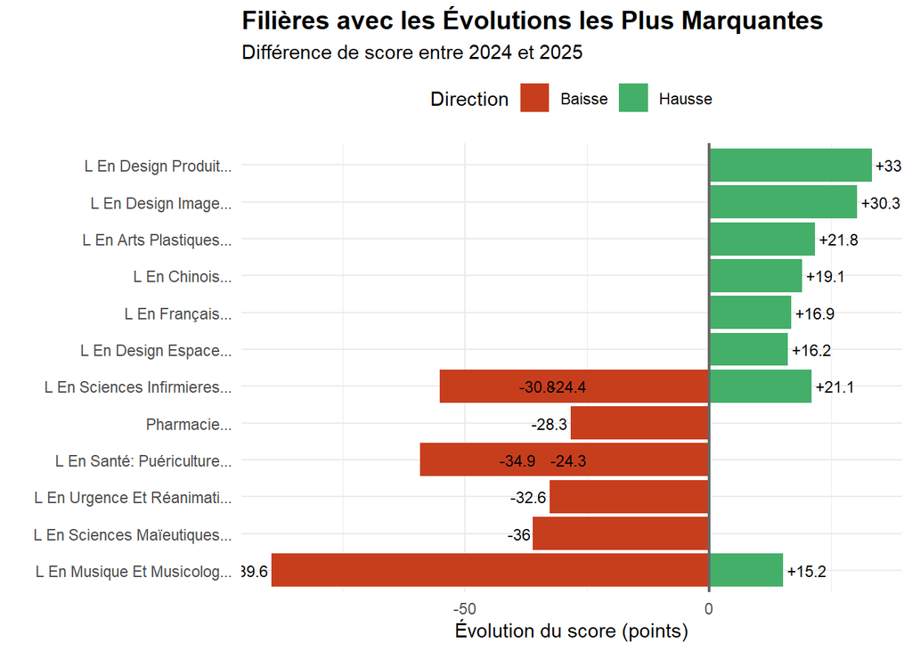

```r
# Visualisation des évolutions les plus marquantes
top_evolutions <- rbind(
  df_evolution %>% filter(Evolution < 0) %>% head(8),
  df_evolution %>% filter(Evolution > 0) %>% arrange(desc(Evolution)) %>% head(8)
)

ggplot(top_evolutions, aes(x = reorder(paste0(substr(str_to_title(Filiere), 1, 25), "..."), Evolution),
                           y = Evolution, fill = Direction)) +
  geom_col() +
  geom_text(aes(label = paste0(ifelse(Evolution > 0, "+", ""), round(Evolution, 1))),
            hjust = ifelse(top_evolutions$Evolution > 0, -0.1, 1.1), size = 3) +
  coord_flip() +
  scale_fill_manual(values = c("Hausse" = "#44AF69", "Baisse" = "#C73E1D")) +
  labs(
    title = "Filières avec les Évolutions les Plus Marquantes",
    subtitle = "Différence de score entre 2024 et 2025",
    x = "",
    y = "Évolution du score (points)",
    fill = "Direction"
  ) +
  theme_minimal(base_size = 11) +
  theme(
    plot.title = element_text(face = "bold", size = 14),
    legend.position = "top"
  ) +
  geom_hline(yintercept = 0, color = "gray40", size = 0.8)
```

## 3.13 12. Tableau de Synthèse par Domaine

```r
# Tableau récapitulatif par domaine
synthese_domaine <- df %>%
  group_by(Domaine) %>%
  summarise(
    `Nb Filières` = n(),
    `Score Min 2025` = round(min(Score_2025, na.rm = TRUE), 1),
    `Score Max 2025` = round(max(Score_2025, na.rm = TRUE), 1),
    `Score Moyen 2025` = round(mean(Score_2025, na.rm = TRUE), 1),
    `Évolution Moy.` = round(mean(Evolution, na.rm = TRUE), 1),
    `% Sans Contraintes` = round(sum(Conditions == "aucune") / n() * 100, 0)
  ) %>%
  arrange(desc(`Nb Filières`))

cat("tableau de synthèse par domaine\n\n")
```

```
tableau de synthèse par domaine
```

```r
# Affichage du tableau formaté avec knitr::kable
synthese_display <- synthese_domaine %>%
  rename(
    "Domaine" = "Domaine",
    "Nb Filières" = "Nb Filières",
    "Score Min" = "Score Min 2025",
    "Score Max" = "Score Max 2025",
    "Score Moyen" = "Score Moyen 2025",
    "Évolution" = "Évolution Moy.",
    "% Sans Contraintes" = "% Sans Contraintes"
  ) %>%
  mutate(across(where(is.numeric), ~round(., 1)))

knitr::kable(synthese_display,
             format = "simple",
             digits = 1,
             caption = "Tableau de Synthèse par Domaine d'Études")
```

Tableau de Synthèse par Domaine d’Études

| Domaine | Nb Filières | Score Min | Score Max | Score Moyen | Évolution | % Sans Contraintes |
| --- | --- | --- | --- | --- | --- | --- |
| Langues | 70 | 67.5 | 144.5 | 90.6 | -1.4 | 67 |
| Arts & Design | 56 | 0.0 | 138.5 | 103.6 | -0.5 | 100 |
| Sante | 29 | 88.2 | 173.2 | 142.8 | -2.4 | 3 |
| Sciences Humaines | 29 | 79.2 | 138.2 | 96.9 | 2.4 | 90 |
| Autres | 14 | 76.4 | 139.0 | 111.5 | -0.2 | 57 |
| Droit & Social | 11 | 100.9 | 139.5 | 111.8 | -0.6 | 100 |
| Education | 11 | 119.1 | 138.3 | 127.5 | 7.1 | 9 |
| Communication | 4 | 96.5 | 105.5 | 100.3 | -1.4 | 75 |
| Sport | 4 | 137.0 | 141.8 | 138.7 | -8.2 | 0 |
| Sciences Islamiques | 3 | 95.4 | 104.6 | 100.4 | 1.0 | 100 |
| Traduction | 3 | 77.3 | 103.3 | 92.0 | -2.4 | 100 |
| Architecture | 2 | 121.8 | 158.3 | 140.0 | -2.6 | 100 |
| Tourisme | 2 | 111.3 | 112.3 | 111.8 | 3.1 | 100 |

```r
cat("\n\nlégende:\n")
```

```
légende:
```

```r
cat("   - score min/max/moyen 2025: scores d'orientation (plus bas = plus accessible)\n")
```

```
   - score min/max/moyen 2025: scores d'orientation (plus bas = plus accessible)
```

```r
cat("   - evolution: différence moyenne entre 2024 et 2025 (négatif = baisse)\n")
```

```
   - evolution: différence moyenne entre 2024 et 2025 (négatif = baisse)
```

```r
cat("   - % sans contraintes: pourcentage de filières sans conditions spéciales\n")
```

```
   - % sans contraintes: pourcentage de filières sans conditions spéciales
```

# 4 Conclusions et Recommandations

## 4.1 Synthèse des Résultats

```r
# Génération automatique des conclusions
cat("conclusions de l'analyse exploratoire\n\n")
```

```
conclusions de l'analyse exploratoire
```

```r
# Contexte
cat("contexte du bac lettres 2025\n")
```

```
contexte du bac lettres 2025
```

```r
cat("   - taux de réussite 2024: 44.33%\n")
```

```
   - taux de réussite 2024: 44.33%
```

```r
cat("   - taux de réussite 2025: 39.10% (-5.23 points)\n")
```

```
   - taux de réussite 2025: 39.10% (-5.23 points)
```

```r
cat("   - impact: moins de bacheliers, potentiellement moins de compétition\n\n")
```

```
   - impact: moins de bacheliers, potentiellement moins de compétition
```

```r
# Offre de formation
cat("offre de formation\n")
```

```
offre de formation
```

```r
cat("   - nombre total de filières:", nrow(df), "\n")
```

```
   - nombre total de filières: 238
```

```r
cat("   - nombre d'universités:", n_distinct(df$Universite), "\n")
```

```
   - nombre d'universités: 12
```

```r
cat("   - nombre d'établissements:", n_distinct(df$Etablissement), "\n")
```

```
   - nombre d'établissements: 83
```

```r
cat("   - gouvernorats couverts:", n_distinct(df$Gouvernorat), "\n\n")
```

```
   - gouvernorats couverts: 19
```

```r
# Évolution des scores
nb_baisse <- sum(df$Evolution < 0, na.rm = TRUE)
nb_hausse <- sum(df$Evolution > 0, na.rm = TRUE)
cat("évolution des scores 2024 -> 2025\n")
```

```
évolution des scores 2024 -> 2025
```

```r
cat("   - filières en baisse:", nb_baisse, "(", round(nb_baisse/nrow(df)*100, 1), "%)\n")
```

```
   - filières en baisse: 113 ( 47.5 %)
```

```r
cat("   - filières en hausse:", nb_hausse, "(", round(nb_hausse/nrow(df)*100, 1), "%)\n")
```

```
   - filières en hausse: 122 ( 51.3 %)
```

```r
cat("   - évolution moyenne:", round(mean(df$Evolution, na.rm = TRUE), 2), "points\n\n")
```

```
   - évolution moyenne: -0.43 points
```

```r
# Accessibilité
score_median <- median(df$Score_2025, na.rm = TRUE)
nb_accessibles <- sum(df$Score_2025 <= 100, na.rm = TRUE)
cat("accessibilité\n")
```

```
accessibilité
```

```r
cat("   - score médian 2025:", round(score_median, 2), "\n")
```

```
   - score médian 2025: 104.19
```

```r
cat("   - filières avec score ≤ 100:", nb_accessibles, "(", round(nb_accessibles/nrow(df)*100, 1), "%)\n")
```

```
   - filières avec score ≤ 100: 107 ( 45 %)
```

```r
cat("   - filières sans contraintes:", sum(df$Conditions == "aucune"), "(", round(sum(df$Conditions == "aucune")/nrow(df)*100, 1), "%)\n")
```

```
   - filières sans contraintes: 163 ( 68.5 %)
```

## 4.2 Recommandations pour les Bacheliers Lettres 2026

**Contexte** : Avec un taux de réussite de 39.10% en 2025 (baisse de 5.23 points par rapport à 2024), les bacheliers Lettres 2026 doivent adopter une stratégie d’orientation réfléchie.

### 4.2.1 Opportunités à saisir :

| Domaine | Avantages | Score Moyen |
| --- | --- | --- |
| **Langues** (français, arabe, anglais) | Scores accessibles, peu de contraintes | ~90 points |
| **Sciences Humaines** (histoire, géographie, philosophie) | Bonne diversité, débouchés variés | ~97 points |
| **Arts & Design** | Profils créatifs, options diversifiées | ~104 points |
| **Communication & Journalisme** | Secteur en expansion | ~100 points |

### 4.2.2 Filières sélectives - Préparation intensive requise :

[output not shown]

### 4.2.5 Plan d’action recommandé :

1. **Identifier 3-5 filières cibles** dans différentes gammes de scores
2. **Vérifier les contraintes** (sport, SVT, âge) pour chaque choix
3. **Diversifier géographiquement** pour maximiser les chances
4. **Suivre les tendances** des scores entre 2024 et 2025 comme indicateur

## 4.3 Données et Méthodologie

- **Période** : Sessions 2024 et 2025
- **Source** : Données officielles d’orientation universitaire - Ministère de l’Enseignement Supérieur, Tunisie
- **Traitement** : Nettoyage et standardisation via R (voir Phase I)
- **Échantillon** : 238 filières, 12 universités, 19 gouvernorats
- **Outils** : R, tidyverse, ggplot2, viridis, knitr